The app code is designed in a way that it generates the UI dynamically (including filtering variables and their values) based on a simple schema of an input CSV file.

## Input CSV file schema

CSV input file should consist on 2 groups of columns.

#### Group 1

Group 1 are study meta information columns:

- study ID/name (`"Study"` column name),
- study URL link (`"Url"` column name),
- other meta information variables (currently hard-coded: `"Title"`, `"Info"`, `"Summary"`).

Note:

- All variables in this grup should be `character` type.
- All but Study ID/name (`"Study"` column name) can be left blank for one/many/all studies.
- All but Study ID/name (`"Study"` column name) and URL link (`"Url"` column name) can be modified easily (in app .R file top part).

#### Group 2

Group 2 are study variable and its value columns. They are build in the following way:

- `"STUDY_VARIABLE=STUDY_VARIABLE_VALUE"`.

Note:

- All variables in this grup should be `numeric`/`integer` type and only take value `0` or `1`.
- The `STUDY_VARIABLE_VALUE` part of column name can contain spaces and special characters (i.e., `+`), but cannot contain `=` sign.

#### Example

Example of input CSV file schema is located at data/data-foo.csv. It was simulated with the use of R script R/simulate-foo-data.R.

## Filtering logic

The filtering logic works as follows: for a study to pass the filter, the selected variable value in filter must  
have value `1` in CSV input file for corresponding `"STUDY_VARIABLE=STUDY_VARIABLE_VALUE"` variable, and this agreement must be kept for all variables the filter defines (the CSV file defines).

## Screenshot

The properly launched app should look like this:

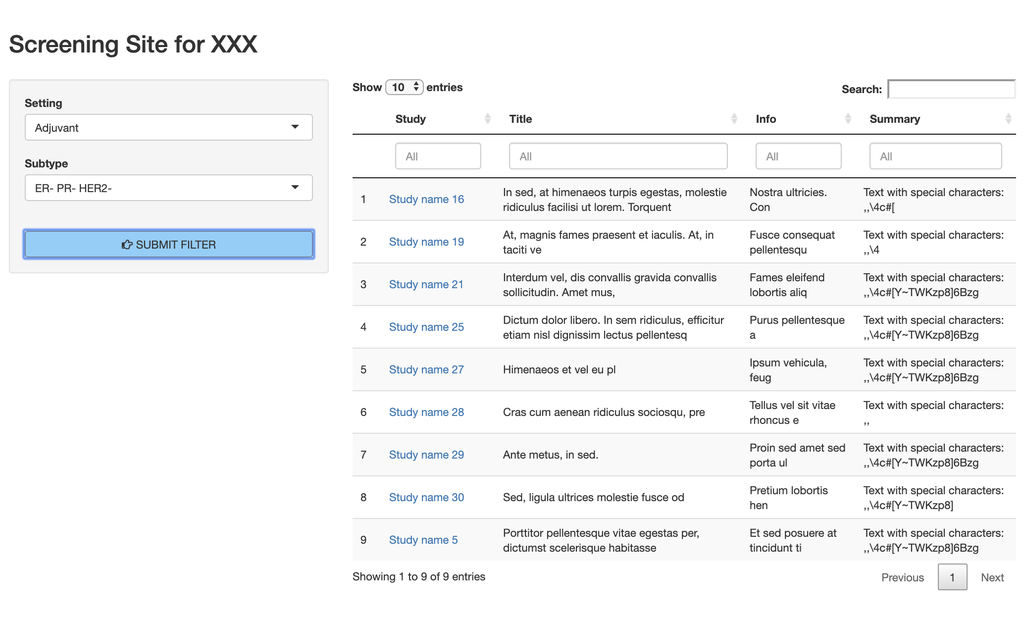